# Reproduced analyses from project report

2026-06-04

1. Load libraries and data

```r
library(phyloseq)
library(vegan)
library(dplyr)
library(tibble)
library(purrr)
library(stringr)
library(ggplot2)
library(tidyverse)
library(ggh4x)
library(picante)
library(reshape2)
library(gridExtra)
library(grid)

wd <- getwd()
file_path <- file.path(wd, "data", "molecular_ecology_17695.rds")
Cats <- readRDS(file_path)
Cats_ps <- Cats$phyloseq
sample_df <- sample_data(Cats_ps) %>% data.frame()
```

2. Table 1: Sample counts per location and origin

```r
table1 <- sample_df %>%
  count(location, origin) %>%
  pivot_wider(names_from = origin, values_from = n, values_fill = 0)
knitr::kable(table1, caption = "Table 1: Number of samples by location and origin")
```

Table 1: Number of samples by location and origin

| location | Domestic | Feral |
| --- | --- | --- |
| Aruba | 9 | 7 |
| Brazil | 8 | 8 |
| CaboVerde | 12 | 3 |
| Denmark | 6 | 9 |
| Malaysia | 8 | 7 |
| Spain | 8 | 7 |

3. Figure 2: Relative abundance bar plot (genus level)

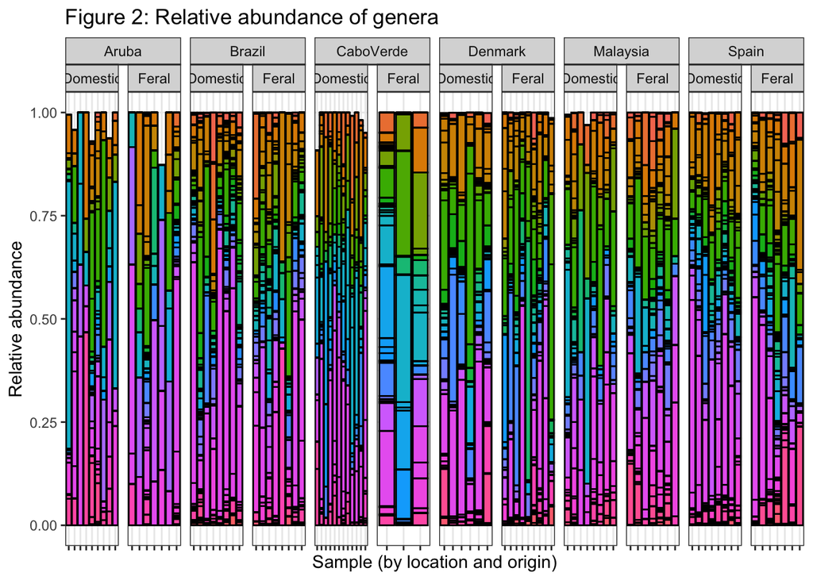

```r
ps_rel <- transform_sample_counts(Cats_ps, function(x) x / sum(x))
ps_genus <- tax_glom(ps_rel, taxrank = "genus")
plot_bar(ps_genus, fill = "genus") +
  facet_nested(~ location + origin, scales = "free_x") +
  theme_bw() +
  theme(axis.text.x = element_blank(), legend.position = "none") +
  labs(title = "Figure 2: Relative abundance of genera",
       x = "Sample (by location and origin)", y = "Relative abundance")
```

Figure 3: MAG completness vs comtamination

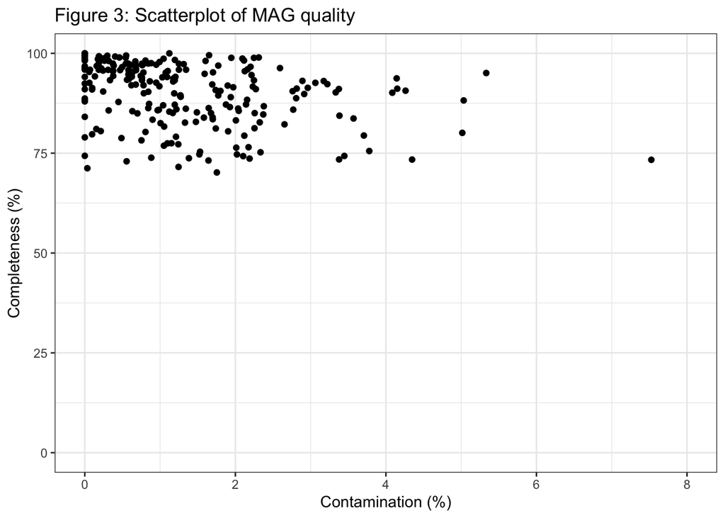

```r
Cats_mag <- Cats$mag_info
ggplot(Cats_mag, aes(x = contamination, y = completeness)) +
  geom_point() +
  xlim(0, 8) + ylim(0, 100) +
  labs(x = "Contamination (%)", y = "Completeness (%)",
       title = "Figure 3: Scatterplot of MAG quality") +
  theme_bw()
```

Alpha diversity

Calculate Shannon, Observed richnedd and Faith’s PD

```r
ps_pa <- transform_sample_counts(Cats_ps, function(x) ifelse(x > 0, 1, 0))

shannon <- estimate_richness(Cats_ps, measures = "Shannon") %>%
  rownames_to_column("sample_id")
observed <- estimate_richness(ps_pa, measures = "Observed") %>%
  rownames_to_column("sample_id")

otu_mat <- as(otu_table(Cats_ps), "matrix")
if (taxa_are_rows(Cats_ps)) otu_mat <- t(otu_mat)
pd_val <- pd(otu_mat, phy_tree(Cats_ps), include.root = FALSE) %>%
  rownames_to_column("sample_id") %>% select(sample_id, PD, SR)

alpha_all <- inner_join(shannon, observed, by = "sample_id") %>%
  inner_join(pd_val, by = "sample_id") %>%
  inner_join(sample_df %>% rownames_to_column("sample_id"), by = "sample_id")

alpha_long <- alpha_all %>%
  select(sample_id, location, origin, Shannon, Observed, PD) %>%
  pivot_longer(cols = c(Shannon, Observed, PD), names_to = "metric", values_to = "value")
```

Table 2: Kruskal-Wallis p-valuse by location and origin

```r
kruskal_loc <- alpha_long %>%
  group_by(metric) %>%
  summarise(p_location = kruskal.test(value ~ location)$p.value)
kruskal_orig <- alpha_long %>%
  group_by(metric) %>%
  summarise(p_origin = kruskal.test(value ~ origin)$p.value)
table2 <- inner_join(kruskal_loc, kruskal_orig, by = "metric")
knitr::kable(table2, caption = "Table 2: Kruskal‑Wallis p‑values for alpha diversity metrics", digits = 4)
```

Table 2: Kruskal‑Wallis p‑values for alpha diversity metrics

| metric | p_location | p_origin |
| --- | --- | --- |
| Observed | 0e+00 | 0.4625 |
| PD | 0e+00 | 0.6515 |
| Shannon | 5e-04 | 0.2836 |

Figure 4: Boxplot comparison across methods

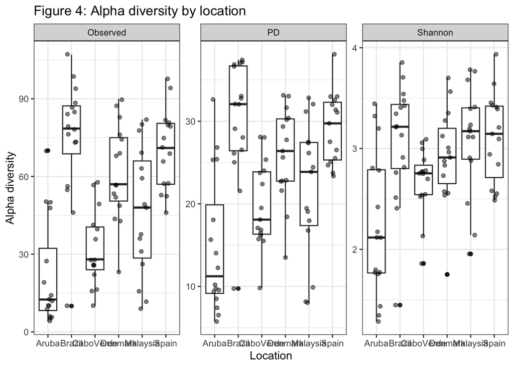

```r
ggplot(alpha_long, aes(x = location, y = value)) +
  geom_boxplot() +
  geom_jitter(width = 0.2, alpha = 0.5) +
  facet_wrap(~ metric, scales = "free_y") +
  theme_bw() +
  labs(y = "Alpha diversity", x = "Location", title = "Figure 4: Alpha diversity by location")
```

Beta diversity

Distance matrices

```r
bray_dist <- distance(ps_rel, method = "bray")
jaccard_dist <- distance(ps_pa, method = "jaccard")
unifrac_dist <- distance(ps_pa, method = "unifrac", weighted = FALSE)
wunifrac_dist <- distance(ps_rel, method = "unifrac", weighted = TRUE)
```

PCoA ordinations and variance explained (Table 3)

```r
ord_bray <- ordinate(ps_rel, method = "PCoA", distance = bray_dist)
ord_jaccard <- ordinate(ps_pa, method = "PCoA", distance = jaccard_dist)
ord_unifrac <- ordinate(ps_pa, method = "PCoA", distance = unifrac_dist)
ord_wunifrac <- ordinate(ps_rel, method = "PCoA", distance = wunifrac_dist)

get_var_exp <- function(ord) {
  eig <- ord$values$Eigenvalues
  var_exp <- eig / sum(eig)
  data.frame(Axis = paste0("Axis.", 1:2),
             Variance = round(var_exp[1:2], 4),
             Cumulative = round(cumsum(var_exp)[1:2], 4))
}
var_df <- rbind(
  cbind(Method = "Bray-Curtis", get_var_exp(ord_bray)),
  cbind(Method = "Jaccard", get_var_exp(ord_jaccard)),
  cbind(Method = "Unweighted UniFrac", get_var_exp(ord_unifrac)),
  cbind(Method = "Weighted UniFrac", get_var_exp(ord_wunifrac))
)
knitr::kable(var_df, caption = "Table 3: Variance explained by first two PCoA axes")
```

Table 3: Variance explained by first two PCoA axes

| Method | Axis | Variance | Cumulative |
| --- | --- | --- | --- |
| Bray-Curtis | Axis.1 | 0.1571 | 0.1571 |
| Bray-Curtis | Axis.2 | 0.1150 | 0.2721 |
| Jaccard | Axis.1 | 0.2135 | 0.2135 |
| Jaccard | Axis.2 | 0.0759 | 0.2894 |
| Unweighted UniFrac | Axis.1 | 0.2998 | 0.2998 |
| Unweighted UniFrac | Axis.2 | 0.0851 | 0.3849 |
| Weighted UniFrac | Axis.1 | 0.2710 | 0.2710 |
| Weighted UniFrac | Axis.2 | 0.2079 | 0.4789 |

Figure 5: Dispersion plots by origin (2x2 layout)

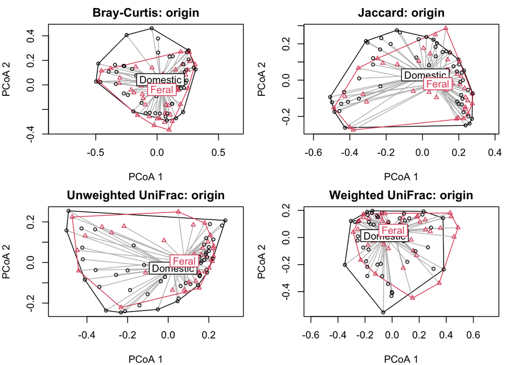

```r
disp_bray_origin <- betadisper(bray_dist, sample_df$origin)
disp_jaccard_origin <- betadisper(jaccard_dist, sample_df$origin)
disp_unifrac_origin <- betadisper(unifrac_dist, sample_df$origin)
disp_wunifrac_origin <- betadisper(wunifrac_dist, sample_df$origin)

# Set smaller margins and 2x2 layout
par(mfrow = c(2, 2), mar = c(4, 4, 2, 1))
plot(disp_bray_origin, main = "Bray-Curtis: origin")
plot(disp_jaccard_origin, main = "Jaccard: origin")
plot(disp_unifrac_origin, main = "Unweighted UniFrac: origin")
plot(disp_wunifrac_origin, main = "Weighted UniFrac: origin")
```

```r
par(mfrow = c(1, 1))  # reset
```

Figure 6: Dispersion plots by location (2x2 layout)

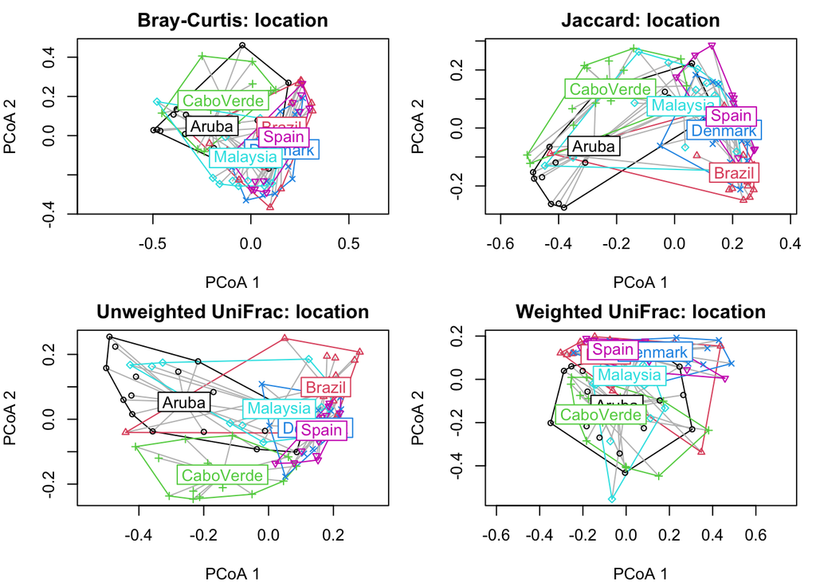

```r
disp_bray_loc <- betadisper(bray_dist, sample_df$location)
disp_jaccard_loc <- betadisper(jaccard_dist, sample_df$location)
disp_unifrac_loc <- betadisper(unifrac_dist, sample_df$location)
disp_wunifrac_loc <- betadisper(wunifrac_dist, sample_df$location)

par(mfrow = c(2, 2), mar = c(4, 4, 2, 1))
plot(disp_bray_loc, main = "Bray-Curtis: location")
plot(disp_jaccard_loc, main = "Jaccard: location")
plot(disp_unifrac_loc, main = "Unweighted UniFrac: location")
plot(disp_wunifrac_loc, main = "Weighted UniFrac: location")
```

```r
par(mfrow = c(1, 1))
```

Figure 7: NMDS ordinations (2x2)

```r
ord_nmds_bray <- ordinate(ps_rel, method = "NMDS", distance = bray_dist)
```

```
## *** Best solution was not repeated -- monoMDS stopping criteria:
##      3: no. of iterations >= maxit
##     17: stress ratio > sratmax
```

```r
ord_nmds_jaccard <- ordinate(ps_pa, method = "NMDS", distance = jaccard_dist)
```

```
## *** Best solution was not repeated -- monoMDS stopping criteria:
##      1: no. of iterations >= maxit
##     18: stress ratio > sratmax
##      1: scale factor of the gradient < sfgrmin
```

```r
ord_nmds_unifrac <- ordinate(ps_pa, method = "NMDS", distance = unifrac_dist)
```

```
## *** Best solution was not repeated -- monoMDS stopping criteria:
##     19: stress ratio > sratmax
##      1: scale factor of the gradient < sfgrmin
```

```r
ord_nmds_wunifrac <- ordinate(ps_rel, method = "NMDS", distance = wunifrac_dist)
```

```
## *** Best solution was not repeated -- monoMDS stopping criteria:
##      2: no. of iterations >= maxit
##     16: stress ratio > sratmax
##      2: scale factor of the gradient < sfgrmin
```

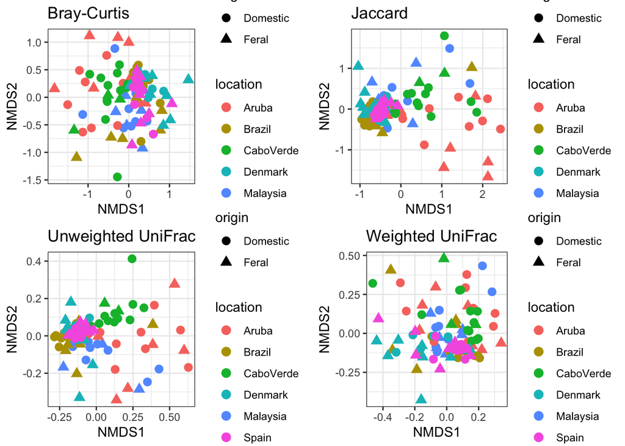

```r
p1 <- plot_ordination(ps_rel, ord_nmds_bray, color = "location", shape = "origin") +
  geom_point(size = 3) + theme_bw() + ggtitle("Bray-Curtis")
p2 <- plot_ordination(ps_pa, ord_nmds_jaccard, color = "location", shape = "origin") +
  geom_point(size = 3) + theme_bw() + ggtitle("Jaccard")
p3 <- plot_ordination(ps_pa, ord_nmds_unifrac, color = "location", shape = "origin") +
  geom_point(size = 3) + theme_bw() + ggtitle("Unweighted UniFrac")
p4 <- plot_ordination(ps_rel, ord_nmds_wunifrac, color = "location", shape = "origin") +
  geom_point(size = 3) + theme_bw() + ggtitle("Weighted UniFrac")

grid.arrange(p1, p2, p3, p4, ncol = 2)
```

PERMANOVA results (reported in text)

```r
adonis_bray_loc <- adonis2(bray_dist ~ location, data = sample_df, permutations = 999)
adonis_bray_orig <- adonis2(bray_dist ~ origin, data = sample_df, permutations = 999)
adonis_jaccard_loc <- adonis2(jaccard_dist ~ location, data = sample_df, permutations = 999)
adonis_unifrac_loc <- adonis2(unifrac_dist ~ location, data = sample_df, permutations = 999)
adonis_wunifrac_loc <- adonis2(wunifrac_dist ~ location, data = sample_df, permutations = 999)

cat("Bray-Curtis ~ location:\n"); print(adonis_bray_loc)
```

```
## Bray-Curtis ~ location:
```

```
## Permutation test for adonis under reduced model
## Permutation: free
## Number of permutations: 999
##
## adonis2(formula = bray_dist ~ location, data = sample_df, permutations = 999)
##          Df SumOfSqs      R2      F Pr(>F)
## Model     5   5.1439 0.18424 3.8847  0.001 ***
## Residual 86  22.7753 0.81576
## Total    91  27.9192 1.00000
## ---
## Signif. codes:  0 '***' 0.001 '**' 0.01 '*' 0.05 '.' 0.1 ' ' 1
```

```r
cat("\nBray-Curtis ~ origin:\n"); print(adonis_bray_orig)
```

```
##
## Bray-Curtis ~ origin:
```

```
## Permutation test for adonis under reduced model
## Permutation: free
## Number of permutations: 999
##
## adonis2(formula = bray_dist ~ origin, data = sample_df, permutations = 999)
##          Df SumOfSqs      R2      F Pr(>F)
## Model     1   0.3917 0.01403 1.2806  0.172
## Residual 90  27.5275 0.98597
## Total    91  27.9192 1.00000
```

```r
cat("\nJaccard ~ location:\n"); print(adonis_jaccard_loc)
```

```
##
## Jaccard ~ location:
```

```
## Permutation test for adonis under reduced model
## Permutation: free
## Number of permutations: 999
##
## adonis2(formula = jaccard_dist ~ location, data = sample_df, permutations = 999)
##          Df SumOfSqs      R2      F Pr(>F)
## Model     5   6.5835 0.24505 5.5829  0.001 ***
## Residual 86  20.2829 0.75495
## Total    91  26.8665 1.00000
## ---
## Signif. codes:  0 '***' 0.001 '**' 0.01 '*' 0.05 '.' 0.1 ' ' 1
```

```r
cat("\nUnweighted UniFrac ~ location:\n"); print(adonis_unifrac_loc)
```

```
##
## Unweighted UniFrac ~ location:
```

```
## Permutation test for adonis under reduced model
## Permutation: free
## Number of permutations: 999
##
## adonis2(formula = unifrac_dist ~ location, data = sample_df, permutations = 999)
##          Df SumOfSqs     R2      F Pr(>F)
## Model     5   4.4706 0.2896 7.0117  0.001 ***
## Residual 86  10.9665 0.7104
## Total    91  15.4371 1.0000
## ---
## Signif. codes:  0 '***' 0.001 '**' 0.01 '*' 0.05 '.' 0.1 ' ' 1
```

```r
cat("\nWeighted UniFrac ~ location:\n"); print(adonis_wunifrac_loc)
```

```
##
## Weighted UniFrac ~ location:
```

```
## Permutation test for adonis under reduced model
## Permutation: free
## Number of permutations: 999
##
## adonis2(formula = wunifrac_dist ~ location, data = sample_df, permutations = 999)
##          Df SumOfSqs      R2      F Pr(>F)
## Model     5    2.827 0.20155 4.3417  0.001 ***
## Residual 86   11.199 0.79845
## Total    91   14.026 1.00000
## ---
## Signif. codes:  0 '***' 0.001 '**' 0.01 '*' 0.05 '.' 0.1 ' ' 1
```

Figure 8: Pairwise PERMANOVA matrices (2x2)

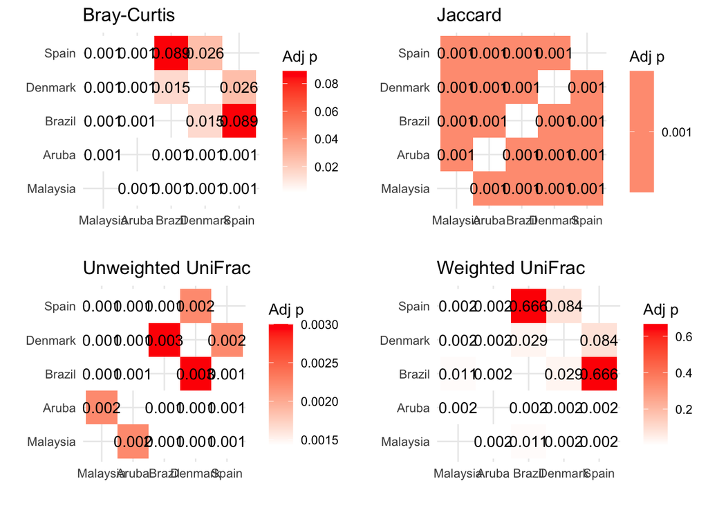

```r
pairwise_permanova_matrix <- function(dist_obj, metadata, group_var, groups_keep) {
  metadata <- metadata[rownames(metadata) %in% rownames(as.matrix(dist_obj)), ]
  meta_sub <- metadata %>% filter(.data[[group_var]] %in% groups_keep) %>% droplevels()
  dist_mat <- as.matrix(dist_obj)
  dist_sub <- dist_mat[rownames(meta_sub), rownames(meta_sub)]
  groups <- unique(meta_sub[[group_var]])
  results <- data.frame()
  for (i in 1:(length(groups)-1)) {
    for (j in (i+1):length(groups)) {
      g1 <- groups[i]; g2 <- groups[j]
      pair_meta <- meta_sub %>% filter(.data[[group_var]] %in% c(g1, g2))
      pair_samples <- rownames(pair_meta)
      pair_dist <- as.dist(dist_sub[pair_samples, pair_samples])
      perm <- adonis2(as.formula(paste("pair_dist ~", group_var)), data = pair_meta, permutations = 999)
      results <- rbind(results, data.frame(group1 = g1, group2 = g2, R2 = perm$R2[1], p = perm$`Pr(>F)`[1]))
    }
  }
  results$p_adj <- p.adjust(results$p, method = "BH")
  mat <- matrix(NA, nrow = length(groups), ncol = length(groups), dimnames = list(groups, groups))
  for (k in 1:nrow(results)) {
    mat[results$group1[k], results$group2[k]] <- results$p_adj[k]
    mat[results$group2[k], results$group1[k]] <- results$p_adj[k]
  }
  return(mat)
}

locations <- c("Spain", "Brazil", "Malaysia", "Denmark", "Carbo Verde", "Aruba")
mat_bray <- pairwise_permanova_matrix(bray_dist, sample_df, "location", locations)
mat_jaccard <- pairwise_permanova_matrix(jaccard_dist, sample_df, "location", locations)
mat_unifrac <- pairwise_permanova_matrix(unifrac_dist, sample_df, "location", locations)
mat_wunifrac <- pairwise_permanova_matrix(wunifrac_dist, sample_df, "location", locations)

plot_matrix <- function(mat, title) {
  df <- melt(mat, na.rm = TRUE)
  ggplot(df, aes(Var1, Var2, fill = value)) +
    geom_tile() + geom_text(aes(label = round(value, 3))) +
    scale_fill_gradient(low = "white", high = "red") +
    theme_minimal() + labs(title = title, x = "", y = "", fill = "Adj p")
}
p_bray <- plot_matrix(mat_bray, "Bray-Curtis")
p_jaccard <- plot_matrix(mat_jaccard, "Jaccard")
p_unifrac <- plot_matrix(mat_unifrac, "Unweighted UniFrac")
p_wunifrac <- plot_matrix(mat_wunifrac, "Weighted UniFrac")

grid.arrange(p_bray, p_jaccard, p_unifrac, p_wunifrac, ncol = 2)
```

Figure 9: Zero-inflation plot

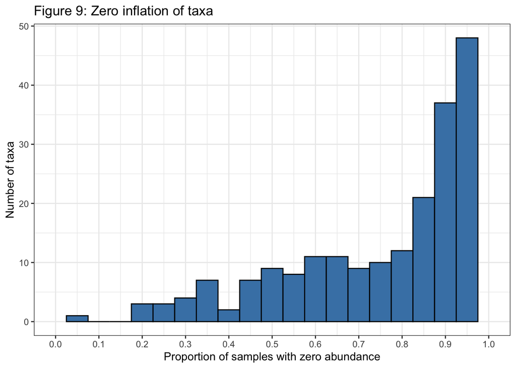

```r
# Calculate proportion of zeros for each taxon across all samples
otu_rel <- as(otu_table(ps_rel), "matrix")
if (taxa_are_rows(ps_rel)) otu_rel <- t(otu_rel)   # samples as rows, taxa as columns

zero_prop <- apply(otu_rel, 2, function(x) mean(x == 0))

zero_df <- data.frame(proportion_zeros = zero_prop)

ggplot(zero_df, aes(x = proportion_zeros)) +
  geom_histogram(binwidth = 0.05, fill = "steelblue", color = "black") +
  scale_x_continuous(limits = c(0, 1), breaks = seq(0, 1, 0.1)) +
  labs(x = "Proportion of samples with zero abundance",
       y = "Number of taxa",
       title = "Figure 9: Zero inflation of taxa") +
  theme_bw()
```

Figure 11: Top enriched taxa (domestic vs feral) per country This figure shows, for each country, the five taxa with the smallest p‑value from a Wilcoxon test comparing domestic vs feral cats.

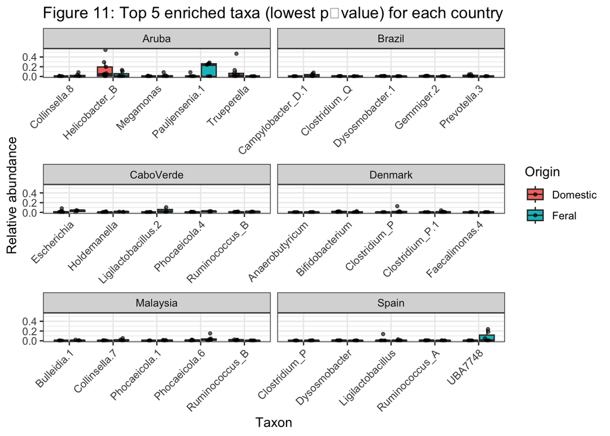

```r
# Extract metadata (only essential columns to avoid name clashes)
meta <- sample_df %>%
  rownames_to_column("sample_id") %>%
  select(sample_id, location, origin)   # keep only needed columns

# Relative abundance matrix (samples as rows)
rel_abund <- as(otu_table(ps_rel), "matrix")
if (taxa_are_rows(ps_rel)) rel_abund <- t(rel_abund)

# Get taxon names (try genus, else OTU)
tax_mat <- tax_table(ps_rel) %>% as.data.frame()
if (nrow(tax_mat) == ncol(rel_abund)) {
  if ("genus" %in% colnames(tax_mat)) {
    taxon_names <- ifelse(is.na(tax_mat$genus) | tax_mat$genus == "",
                          paste0("OTU_", rownames(tax_mat)),
                          tax_mat$genus)
  } else {
    taxon_names <- rownames(tax_mat)
  }
} else {
  taxon_names <- colnames(rel_abund)
}
# Ensure unique names (fixes duplicate genus names)
taxon_names <- make.unique(taxon_names)
colnames(rel_abund) <- taxon_names

# Convert to long format
rel_df <- as.data.frame(rel_abund) %>%
  rownames_to_column("sample_id") %>%
  pivot_longer(-sample_id, names_to = "taxon", values_to = "abundance") %>%
  inner_join(meta, by = "sample_id")   # now safe because meta only has sample_id, location, origin

# List of countries
countries <- unique(meta$location)

# Function to get top 5 taxa for a given country
get_top_taxa <- function(country_name) {
  dat <- rel_df %>% filter(location == country_name)
  # Remove taxa that are all zero in this country
  nonzero_taxa <- dat %>% group_by(taxon) %>% summarise(max_ab = max(abundance)) %>% filter(max_ab > 0) %>% pull(taxon)
  if (length(nonzero_taxa) == 0) return(character(0))
  dat <- dat %>% filter(taxon %in% nonzero_taxa)

  # Wilcoxon test per taxon
  pvals <- dat %>%
    group_by(taxon) %>%
    summarise(
      p = tryCatch(wilcox.test(abundance ~ origin)$p.value, error = function(e) 1),
      logFC = log2(mean(abundance[origin == "Domestic"] + 1e-6) /
                   mean(abundance[origin == "Feral"] + 1e-6)),
      .groups = "drop"
    ) %>%
    arrange(p)

  # Return top 5 (or fewer if not enough taxa)
  head(pvals, 5) %>% pull(taxon)
}

# Get top taxa for each country
top_taxa_per_country <- lapply(setNames(countries, countries), get_top_taxa)

# Keep only those taxa for their respective country
plot_data <- rel_df %>%
  rowwise() %>%
  filter(taxon %in% top_taxa_per_country[[location]]) %>%
  ungroup()

# If no data, skip plot
if (nrow(plot_data) == 0) {
  cat("No significant taxa found for any country.\n")
} else {
  # Plot
  ggplot(plot_data, aes(x = taxon, y = abundance, fill = origin)) +
    geom_boxplot(outlier.shape = NA) +
    geom_jitter(position = position_jitterdodge(jitter.width = 0.2), alpha = 0.6, size = 1) +
    facet_wrap(~ location, scales = "free_x", ncol = 2) +
    theme_bw() +
    theme(axis.text.x = element_text(angle = 45, hjust = 1)) +
    labs(x = "Taxon", y = "Relative abundance",
         fill = "Origin",
         title = "Figure 11: Top 5 enriched taxa (lowest p‑value) for each country")
}
```

Vocano plot: log2 fold change vs significance (per country) This volcano plot displays, for each country, every taxon tested (domestic vs feral).

x‑axis: log₂ fold change (positive = higher in domestic cats, negative = higher in feral cats).

y‑axis: –log₁₀(p‑value) from Wilcoxon test.

Dashed horizontal line: significance threshold (p = 0.05).

Points in red are significant (p < 0.05). The facet layout helps identify countries with stronger domestication signals (e.g., Brazil in the original report). Note: The code adds a small pseudocount (1e-6) to avoid division by zero when calculating fold changes.

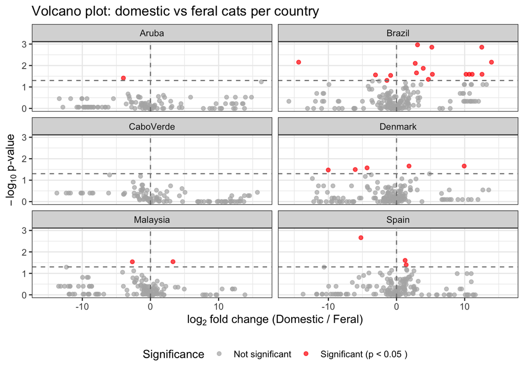

```r
# Compute per country and per taxon
volcano_data <- rel_df %>%
  group_by(location, taxon) %>%
  summarise(
    mean_dom = mean(abundance[origin == "Domestic"], na.rm = TRUE),
    mean_fer = mean(abundance[origin == "Feral"], na.rm = TRUE),
    log2FC = log2((mean_dom + 1e-6) / (mean_fer + 1e-6)),
    p = wilcox.test(abundance ~ origin)$p.value,
    .groups = "drop"
  ) %>%
  mutate(log10p = -log10(p)) %>%
  filter(is.finite(log2FC))   # remove infinite FC values

# Significance threshold
sig_threshold <- 0.05

ggplot(volcano_data, aes(x = log2FC, y = log10p, color = p < sig_threshold)) +
  geom_point(alpha = 0.7, size = 1.5) +
  geom_hline(yintercept = -log10(sig_threshold), linetype = "dashed", color = "gray50") +
  geom_vline(xintercept = 0, linetype = "dashed", color = "gray50") +
  scale_color_manual(values = c("gray70", "red"),
                     labels = c("Not significant", paste("Significant (p <", sig_threshold, ")"))) +
  facet_wrap(~ location, ncol = 2) +
  theme_bw() +
  labs(x = expression(log[2]~"fold change (Domestic / Feral)"),
       y = expression(-log[10]~"p-value"),
       color = "Significance",
       title = "Volcano plot: domestic vs feral cats per country") +
  theme(legend.position = "bottom")
```